# NSW Cancer Institute Skills Test (HSM2)

Dr Zac Wylde

18/11/2021

*This script uses artificial data from the Simulacrum, a synthetic dataset developed by Health Data Insight CiC derived from anonymous cancer data provided by the National Cancer Registration and Analysis Service, which is part of Public Health England.*

Data accessed from: [simulacrum](https://simulacrum.healthdatainsight.org.uk/using-the-simulacrum/requesting-data/)

## Load R Packages

```r
library(tidyverse)
library(janitor)
library(kableExtra)
library(lubridate)
library(freqtables)
library(pwr)
library(plotrix)
library(data.table)
library(ggpubr)
library(sjPlot)
library(lmerTest)
library(DHARMa)
library(ggstatsplot)
```

## Load and check synthetic cancer registration and SACT data for 2013-2015.

*see simulacrum_data_dictionary for definitions.*

**Patient data:** Includes patient demographics from the registry, vital status date and cause of death. Contains Link_Number which allows linkage to SIM_SACT_PATIENT.

```r
## patient data
pat <- read.csv("sim_av_patient.csv")
## contains sex, patient id, ethnicity, causes of death, death location, vital status and other demographic/clinical info

pat <- clean_names(pat)
## returns names in lowercase with _ as separator etc for easier coding, easier life!

names(pat)
str(pat)

names <- c('patientid', 'sex', 'ethnicity', 'deathcausecode_1a', 'deathcausecode_1b',
           'deathcausecode_2', 'deathcausecode_1c', 'deathcausecode_underlying','deathlocationcode', 'newvitalstatus', 'vitalstatusdate')
pat[,names] <- lapply(pat[,names] , factor)
str(pat)
## change these columns to factors (link number for cross-linkage with other data sets and not of interest here)

pat <- pat %>% mutate_all(na_if,"")
## change empty values to NA

levels(pat$sex)
## sex codes in zsex patients file only inclusive of 1, 2, 9 where 1 = Male, 2 = Female, 9 = Not specified
pat <- pat %>% mutate(sex=recode(sex,
                         '1' = "Male",
                         '2' = "Female",
                         '9' = "Unspecified"))

## recoded values for sex for easier plotting/tables later.
```

**Tumour data:** Main tumour table containing details for each tumour registered. Each patient may have more than one tumour. Includes tumourid, age at diagnosis, screening status, demographics, tumour site, staging, TNM staging, grade, tumour morphology, performance status, hormone receptor status, surgery date and deprivation index.

```r
## tumour data
tum <- read.csv("sim_av_tumour.csv")
## contains tumour/patient ids, diagnosis date, a number of morphological measures of tumour, grade, sex of patient,
## SITE_ICD10_O2_3CHAR = site of neoplasm (C34 = lung cancer), comorbidity scores,

tum <- clean_names(tum)

str(tum)

names2 <- c('tumourid', 'patientid', 'diagnosisdatebest', 'site_icd10_o2', 'site_icd10_o2_3char','morph_icd10_o2', 'behaviour_icd10_o2',
           'grade', 'age', 'sex','creg_code', 'linknumber')
tum[,names2] <- lapply(tum[,names2] , factor)
str(tum)
tum <- tum %>% mutate_all(na_if,"")
## change empty values to NA
```

# 1. Analysing data

### **(a) What is the sex distribution of patients?**

Proportion of male and female cancer patients. Assumed that “Unspecified” sex is simply missing data (n = 2) and was thus removed from this dataset. This assumption may be incorrect and possibly represents non-binary or intersex patients who do not identify as male/female.

```r
## table of proportion of males to females (not quite sure exactly how I was supposed to get distribution asked for in brief)
pat1 <- subset(pat, sex == "Male" | sex == "Female")
## because Unspecified is only two observations these were removed

pat1$sex <- droplevels(pat1$sex)
## df still has observations for unspecified (0) need to remove.

tab1 <- pat1 %>%
  group_by (sex) %>%
  summarise (n=n()) %>%
  mutate("Relative Proportion" = paste0(round(100 * n/sum(n), 0), "%"))

table_1 <- tab1 %>%
  kbl() %>%
  kable_styling(c("striped", "hover"), full_width = F)
table_1
```

| sex | n | Relative Proportion |
| --- | --- | --- |
| Male | 1075749 | 49% |
| Female | 1124875 | 51% |

#### Is the difference between the proportion of males and females with cancer significant?

Run basic test for equality of proportions. On face value, the analysis below indicates that this difference is highly significant, suggesting that females are relatively over represented in this data when compared to males.

```r
con_tab <- pat1 %>% freq_table(sex)
## create contingency table to look at relative numbers of male & female patients.

p1 <- prop.test(con_tab$n, con_tab$n_total, p = NULL, correct = F)

p1
```

```
##
##  2-sample test for equality of proportions without continuity
##  correction
##
## data:  con_tab$n out of con_tab$n_total
## X-squared = 2193.3, df = 1, p-value < 2.2e-16
## alternative hypothesis: two.sided
## 95 percent confidence interval:
##  -0.02325768 -0.02138966
## sample estimates:
##    prop 1    prop 2
## 0.4888382 0.5111618
```

#### Calculate Cohen’s *h* effect size for difference between proportions, especially important when examining data with large sample sizes.

The effect size of the difference between proportions is very small (*h* = 0.045) suggesting that even though we rejected the null hypothesis above, the size of the difference between the two proportions is negligible.

```r
h<-ES.h(0.5111618, 0.4888382)

h
```

```
## [1] 0.04465091
```

### **(b) Prepare dataset with all lung cancer patients and their cause of death**

See [definitions here](https://datadictionary.nhs.uk/data_elements/death_cause_icd_code.html).

Subset “site_icd10_o2_3char = C34” from tumour data then migrate to patient dataset.

```r
t1 <- subset(tum, site_icd10_o2_3char == "C34")
## subset tumour data that is only lung cancer patients

pat$site_icd10_o2_3char = t1$site_icd10_o2_3char[match(pat$patientid, t1$patientid)]
## match patient id across data sets and add "site_icd10_o2_3char"
```

Migrate diagnosis date from tumour to patient data then calculate number of days of survival post diagnosis.

```r
pat$diagnosisdatebest = tum$diagnosisdatebest[match(pat$patientid, tum$patientid)]
## match patient id across data sets and add "diagnosisdatebest"

pat$vitalstatusdate <- as.Date(pat$vitalstatusdate)
pat$diagnosisdatebest <- as.Date(pat$diagnosisdatebest)
## make sure R is reading dates properly

pat$survival <- pat$vitalstatusdate - pat$diagnosisdatebest
## deduct dates to get number of days of survival from diagnosis so that can calculate mean survival.
```

Create final data that only includes lung cancer patients and their causes of death.

```r
finalb <- subset(pat, site_icd10_o2_3char == "C34")
## subset only lung cancer patients

write.csv(finalb, "lung_cancer.csv", row.names = F)
## write new data to csv file
```

### **(c) Calculate mean survival time in days for the lung cancer patients who were diagnosed in 2013**

First need to subset by patients that were only diagnosed in 2013.

```r
pat_lc_2013 <- finalb[year(finalb$diagnosisdatebest) == 2013,]
## using lubridate package subset by year 2013
```

Calculate total mean survival time for lung cancer patients (regardless of sex) who were diagnosed in 2013. Not surprisingly the standard deviation is very large indicating that means may not be best measure of central tendency (median would be better). Data is binomial perhaps suggesting that patients who are dead at new vital status had more aggressive cancers and thus shorter survival time. Could also be an artefact of diagnosis date & stage of lung cancer at that date. i.e., cancers detected when in late stages results in shorter survival time and probability of survival.

```r
tab2 <- pat_lc_2013 %>%
  summarise ("survival.mean" = mean(survival, na.rm = T), "survival.sd" = sd(survival), "survial.se" = std.error(survival))

(table_2 <- tab2 %>%
  kbl() %>%
  kable_styling(c("striped", "hover"), full_width = F))
```

| survival.mean | survival.sd | survial.se |
| --- | --- | --- |
| 794.0266 days | 826.032 | 4.289643 |

Visualise distribution of data for both alive and deceased patients.

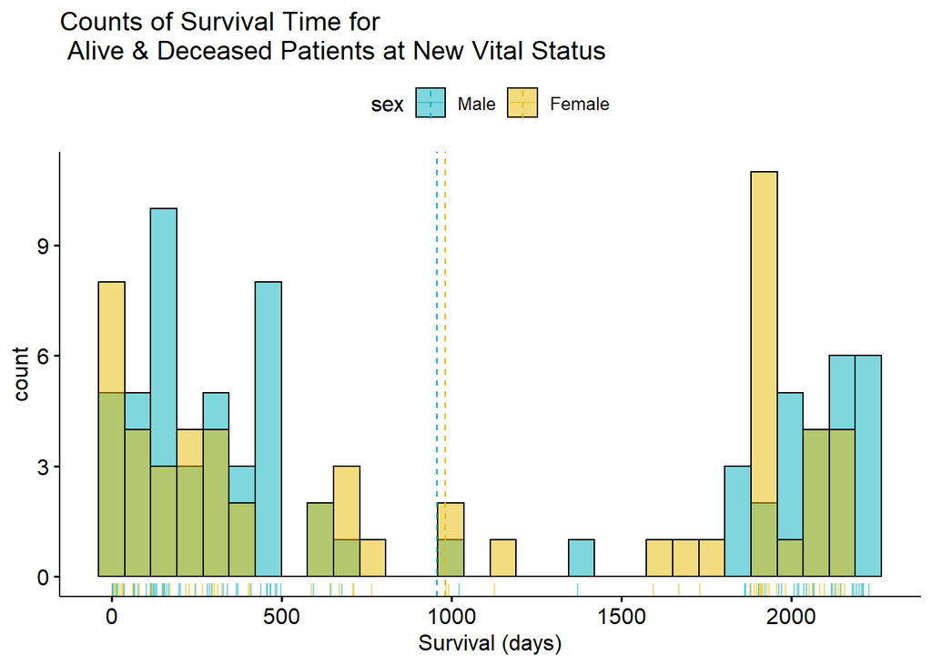

```r
pat_lc_2013$survival <- as.numeric(pat_lc_2013$survival)
##ggplot doesn't like "time diff" format so much so converted to numeric.

(gg1 <- gghistogram(na.omit(pat_lc_2013), x = "survival",
   add = "mean", rug = TRUE,
   fill = "sex", palette = c("#00AFBB", "#E7B800"),
   title = "Counts of Survival Time for \n Alive & Deceased Patients at New Vital Status",
   xlab = "Survival (days)"))
```

Noted that total mean estimate above is conservative as many individuals were alive on last follow up (n = 9358). Individuals that were dead at vital status were 27707. I assume X (exit posting) means that the patient left or moved somewhere else, could not find definition but only n = 16.

Group by vitalstatusdate and calculate means (regardless of sex).

```r
sum1 <- summary(pat_lc_2013$newvitalstatus)

tab4 <- data.table(aggregate(survival ~ newvitalstatus, data = pat_lc_2013,
          FUN = function(x) c(mean = mean(x, na.rm = T), sd = sd(x), se = std.error(x))))
(table_4 <- tab4 %>%
  kbl() %>%
  kable_styling(c("striped", "hover"), full_width = F))
```

| newvitalstatus | survival.mean | survival.sd | survival.se |
| --- | --- | --- | --- |
| A | 2043.7198 | 120.8718 | 1.249492 |
| D | 371.7831 | 449.4601 | 2.700203 |
| X | 1073.5625 | 865.0047 | 216.251184 |

Calculate mean survival but stratified by sex (out of curiosity)

```r
tab3 <- data.table(aggregate(survival ~ sex, data = pat_lc_2013,
          FUN = function(x) c(mean = mean(x, na.rm = T), sd = sd(x), se = std.error(x))))

(table_3 <- tab3 %>%
  kbl() %>%
  kable_styling(c("striped", "hover"), full_width = F))
```

| sex | survival.mean | survival.sd | survival.se |
| --- | --- | --- | --- |
| Male | 807.8130 | 830.2392 | 5.917012 |
| Female | 778.4211 | 820.9883 | 6.225148 |

Visualise distributions for alive and dead patients separately and group by sex with means for each. Data is not normally distributed and shows a lot of variability.

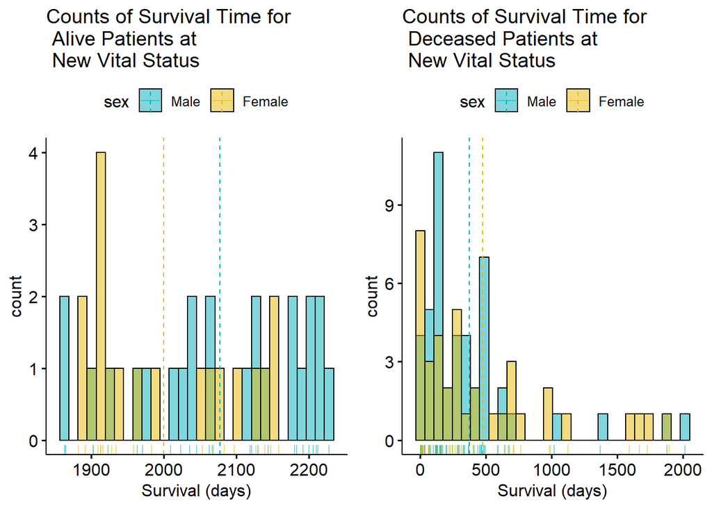

```r
sub1 <- subset(pat_lc_2013, newvitalstatus == "A")
gg2 <- gghistogram(na.omit(sub1), x = "survival",
   add = "mean", rug = TRUE,
   fill = "sex", palette = c("#00AFBB", "#E7B800", "#69b3a2"),
   title = "Counts of Survival Time for \n Alive Patients at \n New Vital Status",
   xlab = "Survival (days)")

sub2 <- subset(pat_lc_2013, newvitalstatus == "D")
gg3 <- gghistogram(na.omit(sub2), x = "survival",
   add = "mean", rug = TRUE,
   fill = "sex", palette = c("#00AFBB", "#E7B800", "#69b3a2"),
   title = "Counts of Survival Time for \n Deceased Patients at \n New Vital Status",
   xlab = "Survival (days)")

ggarrange(gg2, gg3, ncol = 2)
```

# Visualising Data

### **(a) Visualise proportion of all ethnic groups among non-British male patients.**

*See https://datadictionary.nhs.uk/attributes/ethnic_category_code_2001.html for ethnic code definitions.*

Data wrangling to rename factor levels and subset to only non-British male patients, calculate proportions.

```r
lev <- levels(pat$ethnicity)
pat <- pat %>% mutate(ethnicity=recode(ethnicity, '0' = "White", '8' = "Other",'A' = "White British", 'B' = "White Irish", 'CA' = "English",
                                       'C' = "White Other", 'D' = "Mixed Other White", 'E' = "Mixed White African", 'F' = "Mixed White Asian",
                                       'G' = "Mixed Any Other", 'H' = "Indian British", 'J' = "Pakistani British", 'K' = "Bangladeshi British",
                                       'L' = "Asian British", 'M' = "Carribbean British", 'N' = "African British", 'P' = "Black British Other",
                                       'R' = "Chinese", 'S' = "Other Ethnic Groups",'X' = "Not Known", 'Z' = "Not Stated"))
## recoded levels for plotting on complete data in case want to look at trends in females later

male <- subset(pat, sex == "Male")
## subset to only males from full data (not just 2013)

male2 <- subset(male, ethnicity == c("White", "White Irish", "White Other", "Mixed Other White", "Mixed White African", "Mixed White Asian",
                                     "Mixed Any Other", "Chinese", "Other Ethnic Groups", "Other", "Not known", "Not Stated"))
## subset to exclude British males

mal_ethn_prop <- male2 %>% group_by(ethnicity) %>%
  summarise(n = length(ethnicity)) %>%
  mutate(proportion = 100*n/sum(n))
## calculate n and proportions of each group

sum(mal_ethn_prop$proportion)
## double check proportions add to 100
```

Plot relative proportions. Ideally these proportions should be weighted by relative population size of each ethnicity group.

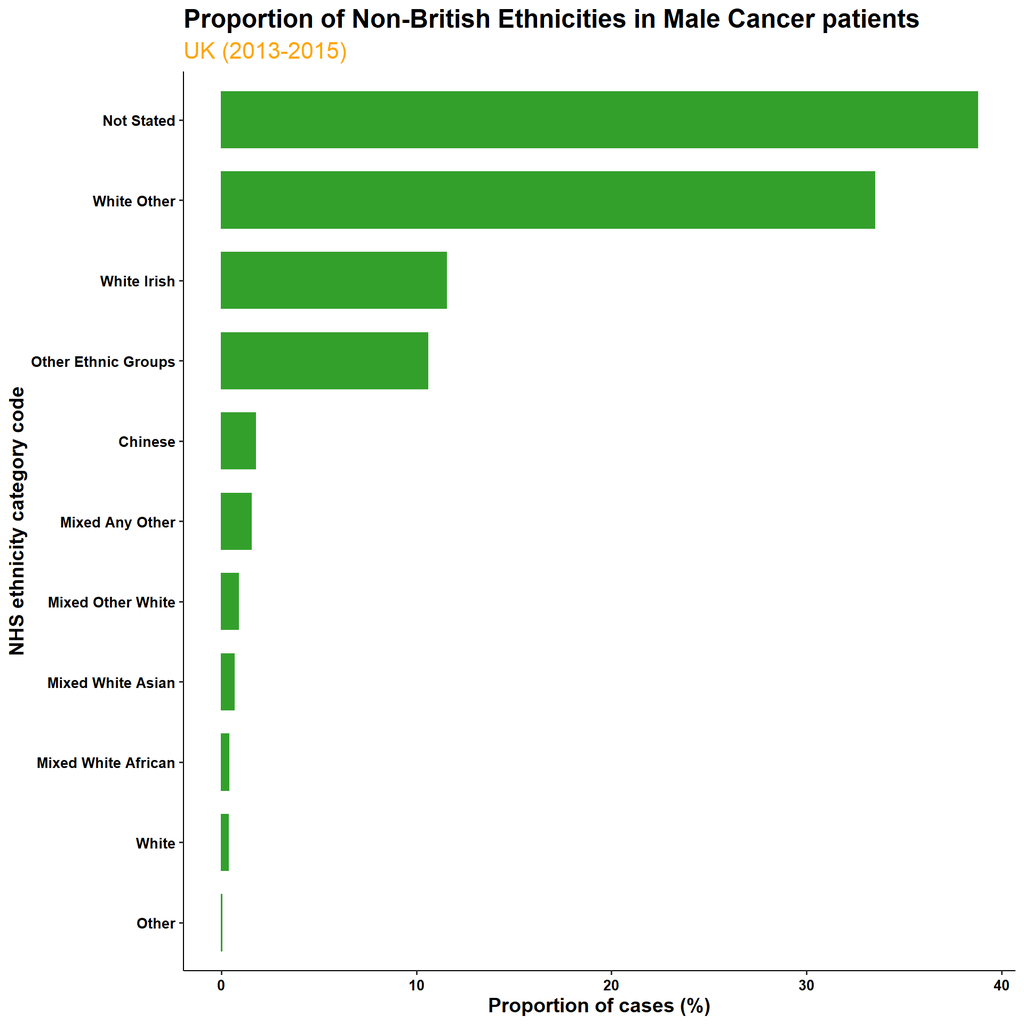

```r
gg4 <-ggbarplot(mal_ethn_prop, x = "ethnicity", y = "proportion",
          fill = "#33A02C",
          color = "#33A02C",
          sort.val = "asc",
          label = F, label.pos = "in",
          position = position_dodge(0.9),
          lab.nb.digits = 2,
          lab.pos = "out",
          sort.by.groups = FALSE,
          x.text.angle = 90,
          xlab = "NHS ethnicity category code",
          ylab = "Proportion of cases (%)",
          title = "Proportion of Non-British Ethnicities in Male Cancer patients",
          subtitle = "UK (2013-2015)",
          rotate = TRUE,
          ggtheme = theme_minimal()
          )


gg5 <- gg4 + rremove("grid") + rremove("y.text") + theme_pubr() +
   font("title", size = 18, color = "black", face = "bold") +
 font("subtitle", size = 16, color = "orange") +
 font("xlab", size = 14, color = "black", face = "bold") +
 font("ylab", size = 14, color = "black", face = "bold") +
 font("xy.text", size = 10, color = "black", face = "bold")

gg5
```

# Examining predictors of survival in brain cancer patients from 2013-2015.

*I became interested in examining the factors that might influence survival time in patients that have brain cancer (ICD10 = C71). See details below for analysis and visualisations.*

#### Data wrangling to add factors of interest.

```r
pat$age = tum$age[match(pat$patientid, tum$patientid)]
## migrate age from tumour and match to patient id

pat$grade = tum$grade[match(pat$patientid, tum$patientid)]
## migrate grade of tumour to patient data set.

pat$date_first_surgery = tum$date_first_surgery[match(pat$patientid, tum$patientid)]
## migrate date of first surgery could be informative predictor of surivival

pat$date_first_surgery <- as.Date(pat$date_first_surgery)
## code as factor
pat$post_diag_surgery <- pat$date_first_surgery - pat$diagnosisdatebest

pat$post_diag_surgery <- as.numeric(pat$post_diag_surgery)
##deduct date of diagnosis from date of first surgery to get number of days.

pat$site_icd10_o2_3char = tum$site_icd10_o2_3char[match(pat$patientid, tum$patientid)]
## match patient id across data sets and add "cancer types"
```

Classification of surgery both pre, on day of and post diagnosis binned into no.days categories.

```r
sub4 <- subset(pat, post_diag_surgery < 0) ## prior to diagnosis
sub4$surg_cat <- 'Prior to diagnosis'

sub5 <- subset(pat, post_diag_surgery == 0) ## on day of diagnosis
sub5$surg_cat <- 'On day of diagnosis'

sub6 <- subset(pat, post_diag_surgery >= 1 & post_diag_surgery <= 28) ## surgery within 1 month of diagnosis
sub6$surg_cat <- '1 month'

sub7 <- subset(pat, post_diag_surgery >= 29 & post_diag_surgery <= 84) ## surgery within 3 months
sub7$surg_cat <- '3 month'

sub8 <- subset(pat, post_diag_surgery >= 85 & post_diag_surgery <= 168) ## surgery within 6 months
sub8$surg_cat <- '6 month'

sub9 <- subset(pat, post_diag_surgery >= 169 & post_diag_surgery <= 336) ## surgery within 12 months
sub9$surg_cat <- '12 month'

sub10 <- subset(pat, post_diag_surgery >= 337) ## surgery over 12 months
sub10$surg_cat <- '12 months +'

sub11 <- rbind(sub4, sub5, sub6, sub7, sub8, sub9, sub10)

sub11$age <- as.numeric(sub11$age)
sub11$surg_cat <- as.factor(sub11$surg_cat)
```

Create age classifications if want to use brackets instead of continuous.

```r
a1 <- subset(sub11, age >= 0 & age <= 14) ## children (no children with skin cancer in data set but if want to test other cancers)
a1$age_cat <- 'Children'

a2 <- subset(sub11, age >= 15 & age <= 24) ## Youth
a2$age_cat <- 'Youth'

a3 <- subset(sub11, age >= 25 & age <= 64) ## adult
a3$age_cat <- 'Adult'

a4 <- subset(sub11, age >= 65) ## senior
a4$age_cat <- 'Senior'

newdat <- rbind(a1, a2, a3, a4)
```

Add in comorbidity and recode factor levels.

```r
newdat$comorbid = as.factor(tum$ace27[match(newdat$patientid, tum$patientid)])
levels(newdat$comorbid)
## 1m, 2m, 3m not listed in look up, assume they are mild, moderate and severe (typos)
newdat <- newdat %>% mutate(comorbid=recode(comorbid,
                         '0' = "None",
                         '1' = "Mild",
                         '2' = "Moderate",
                         '3' = "Severe",
                         '9' = "Unknown",
                         '1m' = "Mild",
                         '2m' = "Moderate",
                         '3m' = "Severe"))
```

Add in behaviour of tumour and recode factor levels.

```r
newdat$tum_behav = tum$behaviour_icd10_o2[match(newdat$patientid, tum$patientid)]

newdat <- newdat %>% mutate(tum_behav=recode(tum_behav,
                         '0' = "Benign",
                         '1' = "Uncertain",
                         '2' = "In situ",
                         '3' = "Malignant",
                         '5' = "Micro-invasive",
                         '6' = "Malignant metastatic",
                         '9' = "Malignant uncertain",
                         'X' = "Unknown/inapplicable"))
```

Add in drug groups

```r
drug <- read.csv("sim_sact_drug_detail.csv")

drug <- clean_names(drug)

newdat$drug = as.factor(drug$drug_group[match(newdat$patientid, drug$merged_patient_id)])
```

Final data wrangling and checking of data structures.

```r
newdat3 <- subset(newdat, site_icd10_o2_3char == "C71")


newdat3$survival <- as.numeric(newdat3$survival)
## change survival again to be numeric

str(newdat3)
## check data structures

names3 <- c('vitalstatusdate', 'diagnosisdatebest', 'date_first_surgery', 'age_cat', 'comorbid')
newdat3[,names3] <- lapply(newdat3[,names3] , factor)
str(newdat3)
## change to factors

newdat4 <- newdat3[ -c(5:10) ]
## drop factors not using for cleanliness!
```

## Exploration of patterns in data.

A quick look at effects of chemo drugs on survival (not included in model below) but seems to show some interesting trends.

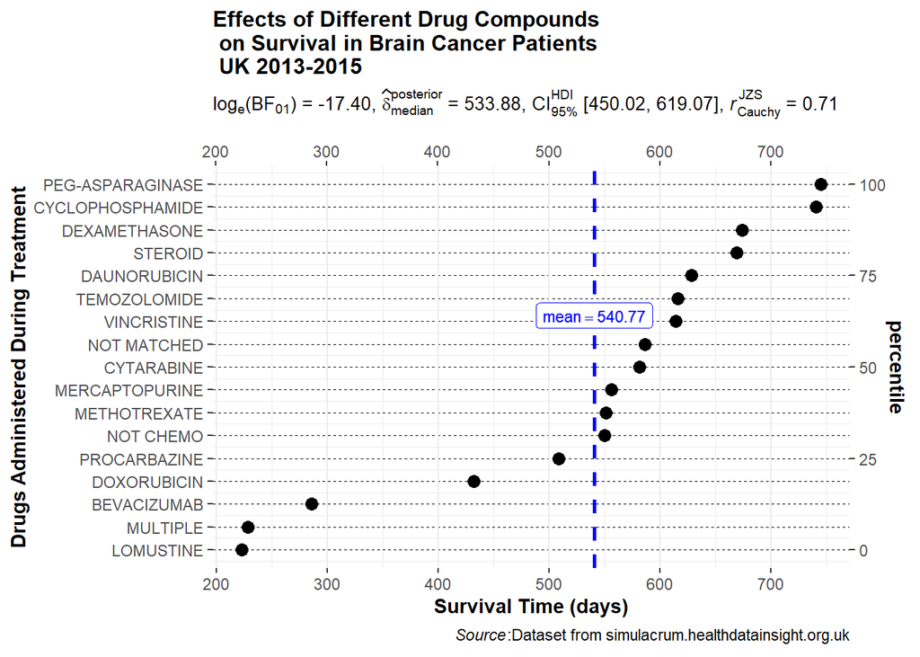

```r
## plot
gg9 <- ggdotplotstats(
  data = newdat4,
  y = drug,
  x = survival,
  type = "bayes",
  title = "Effects of Different Drug Compounds \n on Survival in Brain Cancer Patients \n UK 2013-2015",
  xlab = "Survival Time (days)",
  ylab = "Drugs Administered During Treatment",
  caption = substitute(
    paste(
      italic("Source"),
      ":Dataset from simulacrum.healthdatainsight.org.uk"
    )
  )
)

gg9
```

Effect of time until first surgery on survival.

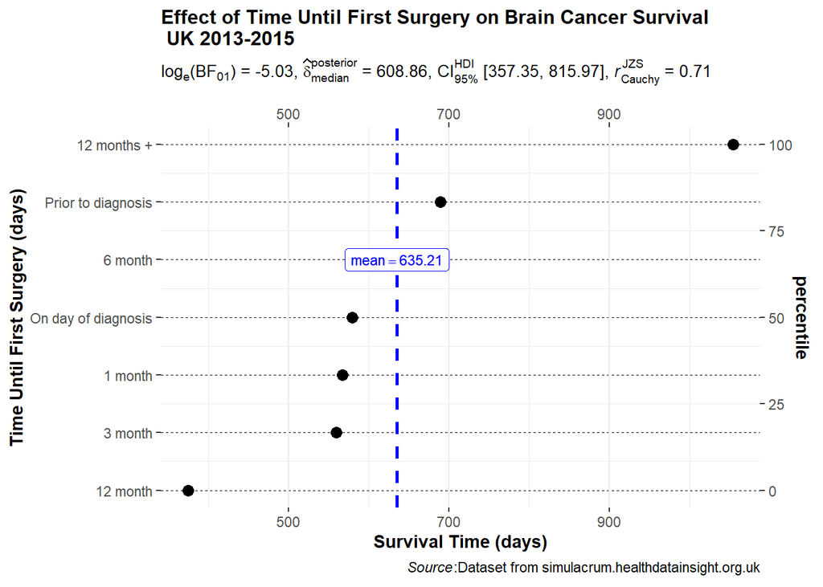

```r
## plot

newdat4$surg_cat <- fct_relevel(newdat4$surg_cat, "On day of diagnosis", "1 month", "3 month", "6 month", "12 month", "12 month +")

gg6 <- ggdotplotstats(
  data = newdat4,
  y = surg_cat,
  x = survival,
  type = "bayes",
  title = "Effect of Time Until First Surgery on Brain Cancer Survival \n UK 2013-2015",
  xlab = "Survival Time (days)",
  ylab = "Time Until First Surgery (days)",
  caption = substitute(
    paste(
      italic("Source"),
      ":Dataset from simulacrum.healthdatainsight.org.uk"
    )
  )
)
gg6
```

Effect of Age on survival (using binned ages).

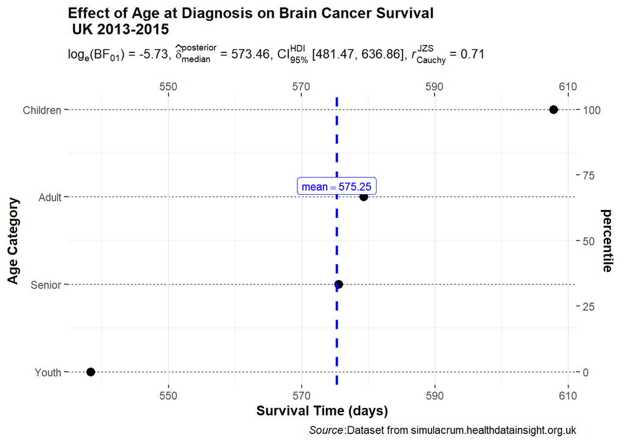

```r
## plot
gg7 <- ggdotplotstats(
  data = newdat4,
  y = age_cat,
  x = survival,
  type = "bayes",
  title = "Effect of Age at Diagnosis on Brain Cancer Survival \n UK 2013-2015",
  xlab = "Survival Time (days)",
  ylab = "Age Category",
  caption = substitute(
    paste(
      italic("Source"),
      ":Dataset from simulacrum.healthdatainsight.org.uk"
    )
  )
)


gg7
```

Comorbidity and survival- something does not seem right here would have expected opposite patterns.

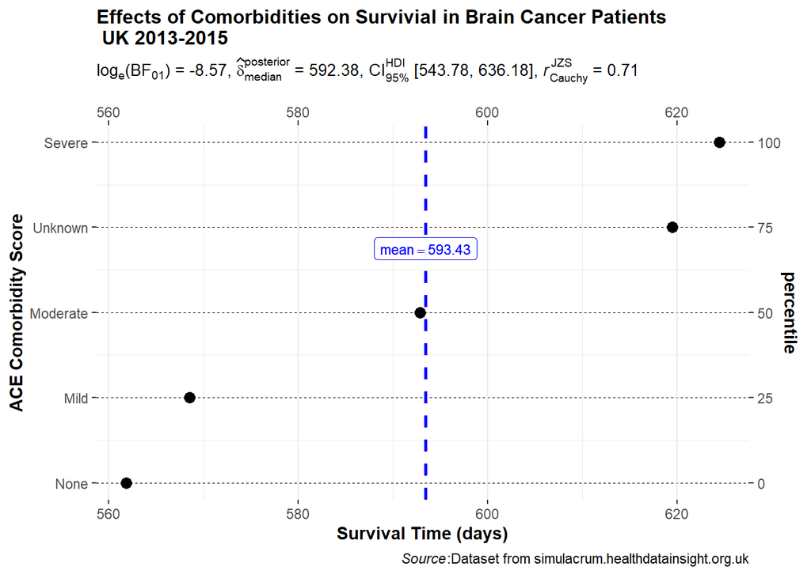

```r
## plot
gg8 <- ggdotplotstats(
  data = newdat4,
  y = comorbid,
  x = survival,
  type = "bayes",
  title = "Effects of Comorbidities on Survivial in Brain Cancer Patients \n UK 2013-2015",
  xlab = "Survival Time (days)",
  ylab = "ACE Comorbidity Score",
  caption = substitute(
    paste(
      italic("Source"),
      ":Dataset from simulacrum.healthdatainsight.org.uk"
    )
  )
)
gg8
```

## Generalised Mixed Model for Survival

I then decided to run a GLMM (preference would be in a Bayesian framework but computer too slow) to see if I could detect any significant effects of age, sex, comorbidities, the time until first surgery and their interactions on the probability of survival for patients with brain cancer.

I controlled for diagnosis date and date of surgery by including as random effects. I did not run a formal model building procedure to choose the best fitting model so please interpret these findings with caution. Diagnostic plot of residuals below suggests the model does not violate assumptions (tests show significance because of large N but residuals fit line nicely suggesting otherwise).

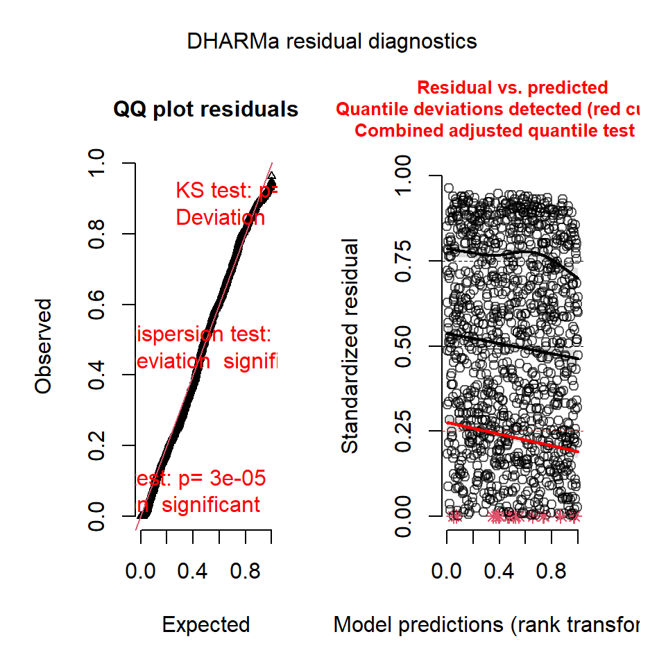

```r
lm1 <- glmer(survival ~  age + sex + post_diag_surgery + comorbid + age*post_diag_surgery + age*comorbid +
            sex*comorbid + post_diag_surgery*comorbid + (1|diagnosisdatebest) + (1|date_first_surgery),
            family = "poisson",
            data = newdat4)
simulationOutput <- simulateResiduals(fittedModel = lm1, plot = T) ## diagnostics showing sig for KS, disperson and outlier because of large N, model looks fine from residual plot.
```

Table Showing the fixed effects and their interactions on survival in Brain cancer patients.

```r
tab_model(lm1)
```

|  | survival |  |  |
| --- | --- | --- | --- |
| Predictors | Incidence Rate Ratios | CI | p |
| (Intercept) | 330.07 | 299.74 – 363.46 | **<0.001** |
| age | 1.00 | 1.00 – 1.00 | **<0.001** |
| sex [Female] | 1.01 | 0.99 – 1.03 | 0.326 |
| post diag surgery | 1.00 | 0.99 – 1.00 | 0.611 |
| comorbid [Mild] | 0.62 | 0.59 – 0.65 | **<0.001** |
| comorbid [Moderate] | 1.36 | 1.30 – 1.42 | **<0.001** |
| comorbid [Severe] | 3.78 | 3.48 – 4.11 | **<0.001** |
| comorbid [Unknown] | 1.18 | 1.14 – 1.23 | **<0.001** |
| age * post diag surgery | 1.00 | 1.00 – 1.00 | 0.290 |
| age * comorbid [Mild] | 1.01 | 1.01 – 1.01 | **<0.001** |
| age * comorbid [Moderate] | 1.00 | 1.00 – 1.00 | **<0.001** |
| age * comorbid [Severe] | 0.98 | 0.98 – 0.99 | **<0.001** |
| age * comorbid [Unknown] | 1.00 | 1.00 – 1.00 | **<0.001** |
| sex [Female] * comorbid [Mild] | 0.92 | 0.89 – 0.95 | **<0.001** |
| sex [Female] * comorbid [Moderate] | 1.53 | 1.48 – 1.58 | **<0.001** |
| sex [Female] * comorbid [Severe] | 0.81 | 0.77 – 0.85 | **<0.001** |
| sex [Female] * comorbid [Unknown] | 0.94 | 0.92 – 0.96 | **<0.001** |
| post diag surgery * comorbid [Mild] | 1.01 | 1.00 – 1.01 | **0.003** |
| post diag surgery * comorbid [Moderate] | 1.00 | 1.00 – 1.01 | 0.077 |
| post diag surgery * comorbid [Severe] | 1.00 | 0.99 – 1.00 | 0.470 |
| post diag surgery * comorbid [Unknown] | 1.00 | 1.00 – 1.01 | **0.049** |
| Random Effects |  |  |  |
| σ<sup>2</sup> | 0.00 |  |  |
| τ<sub>00</sub> <sub>date_first_surgery</sub> | 0.97 |  |  |
| τ<sub>00</sub> <sub>diagnosisdatebest</sub> | 0.72 |  |  |
| ICC | 1.00 |  |  |
| N <sub>diagnosisdatebest</sub> | 767 |  |  |
| N <sub>date_first_surgery</sub> | 788 |  |  |
| Observations | 1148 |  |  |
| Marginal R<sup>2</sup> / Conditional R<sup>2</sup> | 0.022 / 0.999 |  |  |

Plot of Effect sizes from model.

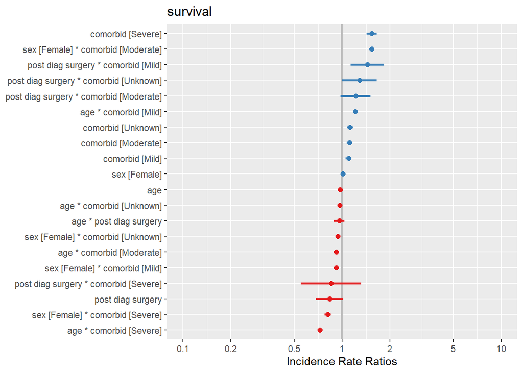

```r
plot_model(lm1, vline.color = "gray", sort.est = TRUE, type = "std", dot.size = 2, line.size = 1, bpe = "mean", bpe.style = "dot",
           prob.inner = 0.4, prob.outer = 0.8)
```

Plot predictions from model for main fixed effects. Some interesting looking trends!